# ipsRdbs: Introduction to Probability, Statistics and R for Data-Based Sciences

## 2.8 `emissions` : Exhaust emissions of cars

Data on the nitrous oxide content of exhaust emissions from a set of cars was collected by the Australian Traffic Accident Research Bureau to explore the relationship between several measures of nitrous oxide emissions. Like the `cheese` data set, this has been used to illustrate multiple linear regression modeling in Chapter 18 of the book Sahu (2024).

```r
summary(emissions)
```

```
#>      Make              Odometer         Capacity         CS505             T867
#>  Length:54          Min.   :  7285   Min.   :1.300   Min.   : 3.675   Min.   : 1.158
#>  Class :character   1st Qu.: 44208   1st Qu.:1.600   1st Qu.: 8.364   1st Qu.: 4.188
#>  Mode  :character   Median : 80164   Median :2.000   Median :10.598   Median : 6.769
#>                     Mean   : 84444   Mean   :2.346   Mean   :10.949   Mean   : 7.217
#>                     3rd Qu.:117248   3rd Qu.:2.900   3rd Qu.:13.125   3rd Qu.:10.001
#>                     Max.   :232574   Max.   :5.000   Max.   :21.475   Max.   :15.982
#>       H505            ADR27           ADR37          logCS505        logT867
#>  Min.   : 1.340   Min.   :0.480   Min.   :0.340   Min.   :1.302   Min.   :0.1466
#>  1st Qu.: 4.884   1st Qu.:1.053   1st Qu.:1.005   1st Qu.:2.124   1st Qu.:1.4322
#>  Median : 8.795   Median :1.475   Median :1.423   Median :2.361   Median :1.9104
#>  Mean   : 9.376   Mean   :1.525   Mean   :1.478   Mean   :2.318   Mean   :1.8185
#>  3rd Qu.:12.906   3rd Qu.:1.981   3rd Qu.:2.029   3rd Qu.:2.575   3rd Qu.:2.3026
#>  Max.   :21.465   Max.   :2.851   Max.   :2.862   Max.   :3.067   Max.   :2.7715
#>     logH505          logADR27           logADR37
#>  Min.   :0.2927   Min.   :-0.73397   Min.   :-1.078810
#>  1st Qu.:1.5850   1st Qu.: 0.05191   1st Qu.: 0.004947
#>  Median :2.1742   Median : 0.38857   Median : 0.352585
#>  Mean   :2.0440   Mean   : 0.33895   Mean   : 0.290615
#>  3rd Qu.:2.5577   3rd Qu.: 0.68382   3rd Qu.: 0.707568
#>  Max.   :3.0664   Max.   : 1.04765   Max.   : 1.051611
```

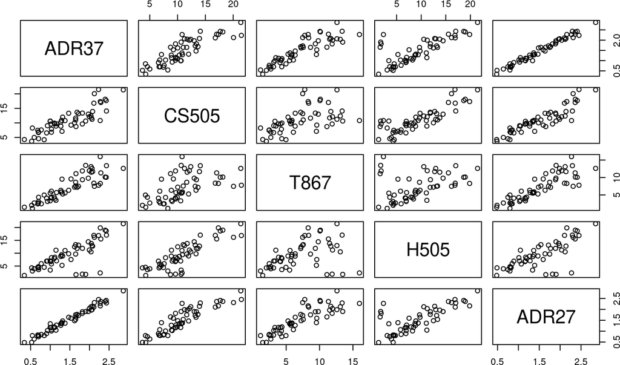

```r
 rawdata <- emissions[, c(8, 4:7)]
 pairs(rawdata)
```

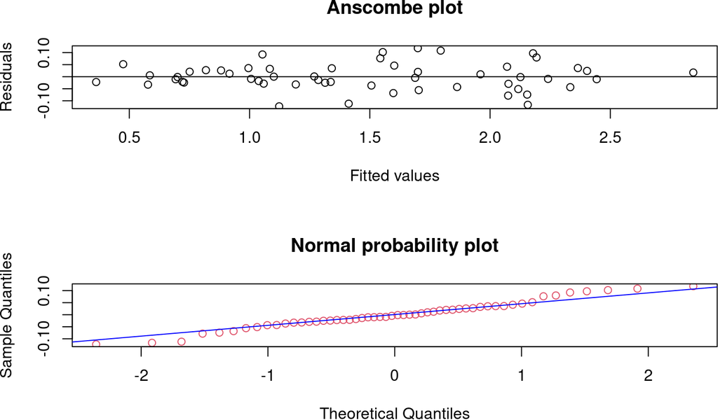

```r
# Fit the model on the raw scale
raw.lm <- lm(ADR37 ~ ADR27 + CS505  + T867 + H505, data=rawdata)
old.par <- par(no.readonly = TRUE)
par(mfrow=c(2,1))
plot(raw.lm$fit, raw.lm$res,xlab="Fitted values",ylab="Residuals", main="Anscombe plot")
abline(h=0)
qqnorm(raw.lm$res,main="Normal probability plot", col=2)
qqline(raw.lm$res, col="blue")
```

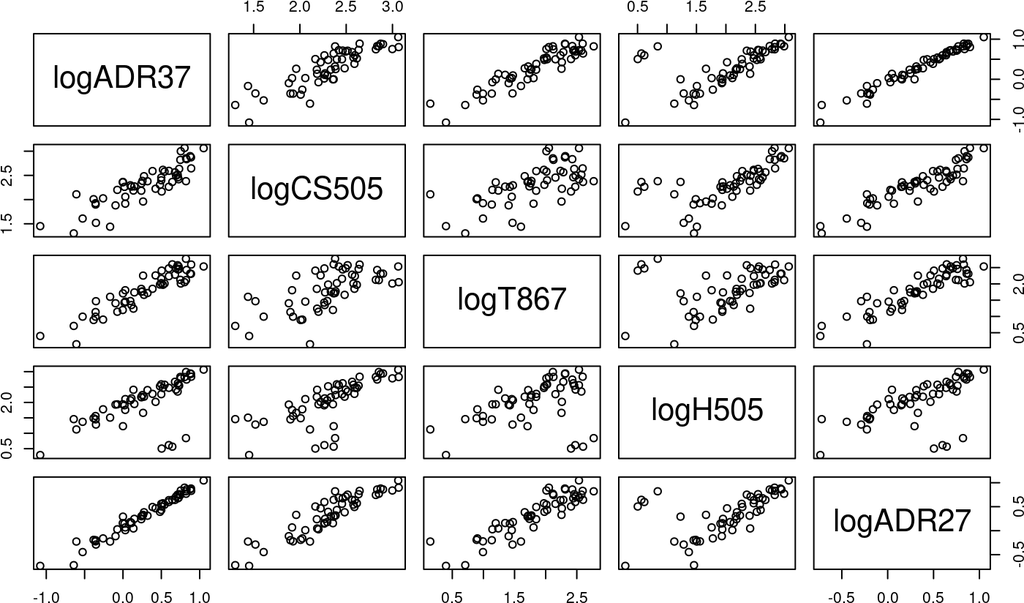

```r
# summary(raw.lm)
logdata <- log(rawdata)
# This only logs the values but not the column names!
# We can use the following command to change the column names or you can use
# fix(logdata) to do it.
dimnames(logdata)[[2]] <- c("logADR37", "logCS505", "logT867", "logH505", "logADR27")
pairs(logdata)
```

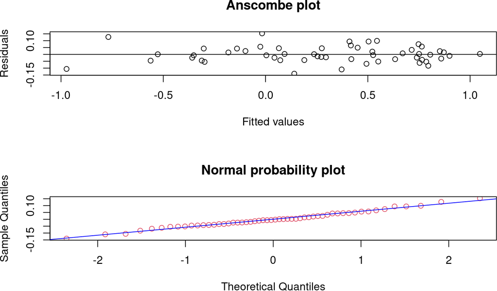

```r
log.lm <- lm(logADR37 ~ logADR27 + logCS505  + logT867 + logH505, data=logdata)
plot(log.lm$fit, log.lm$res,xlab="Fitted values",ylab="Residuals", main="Anscombe plot")
abline(h=0)
qqnorm(log.lm$res,main="Normal probability plot", col=2)
qqline(log.lm$res, col="blue")
```

```r
summary(log.lm)
```

```
#>
#> Call:
#> lm(formula = logADR37 ~ logADR27 + logCS505 + logT867 + logH505,
#>     data = logdata)
#>
#> Residuals:
#>       Min        1Q    Median        3Q       Max
#> -0.140390 -0.038389 -0.003712  0.040204  0.153275
#>
#> Coefficients:
#>             Estimate Std. Error t value Pr(>|t|)
#> (Intercept) -0.12997    0.43073  -0.302 0.764119
#> logADR27     0.94173    0.24140   3.901 0.000292 ***
#> logCS505    -0.16790    0.16086  -1.044 0.301712
#> logT867      0.15736    0.08986   1.751 0.086177 .
#> logH505      0.09997    0.01857   5.385 2.04e-06 ***
#> ---
#> Signif. codes:  0 '***' 0.001 '**' 0.01 '*' 0.05 '.' 0.1 ' ' 1
#>
#> Residual standard error: 0.06038 on 49 degrees of freedom
#> Multiple R-squared:  0.9852, Adjusted R-squared:  0.984
#> F-statistic: 815.9 on 4 and 49 DF,  p-value: < 2.2e-16
```

```r
log.lm2 <- lm(logADR37 ~ logADR27 + logT867 + logH505, data=logdata)
summary(log.lm2)
```

```
#>
#> Call:
#> lm(formula = logADR37 ~ logADR27 + logT867 + logH505, data = logdata)
#>
#> Residuals:
#>       Min        1Q    Median        3Q       Max
#> -0.157932 -0.039221 -0.004817  0.038672  0.157626
#>
#> Coefficients:
#>             Estimate Std. Error t value Pr(>|t|)
#> (Intercept) -0.57484    0.06231  -9.226 2.25e-12 ***
#> logADR27     0.69588    0.05289  13.157  < 2e-16 ***
#> logT867      0.24471    0.03275   7.472 1.10e-09 ***
#> logH505      0.09030    0.01610   5.608 8.85e-07 ***
#> ---
#> Signif. codes:  0 '***' 0.001 '**' 0.01 '*' 0.05 '.' 0.1 ' ' 1
#>
#> Residual standard error: 0.06043 on 50 degrees of freedom
#> Multiple R-squared:  0.9849, Adjusted R-squared:  0.984
#> F-statistic:  1086 on 3 and 50 DF,  p-value: < 2.2e-16
```

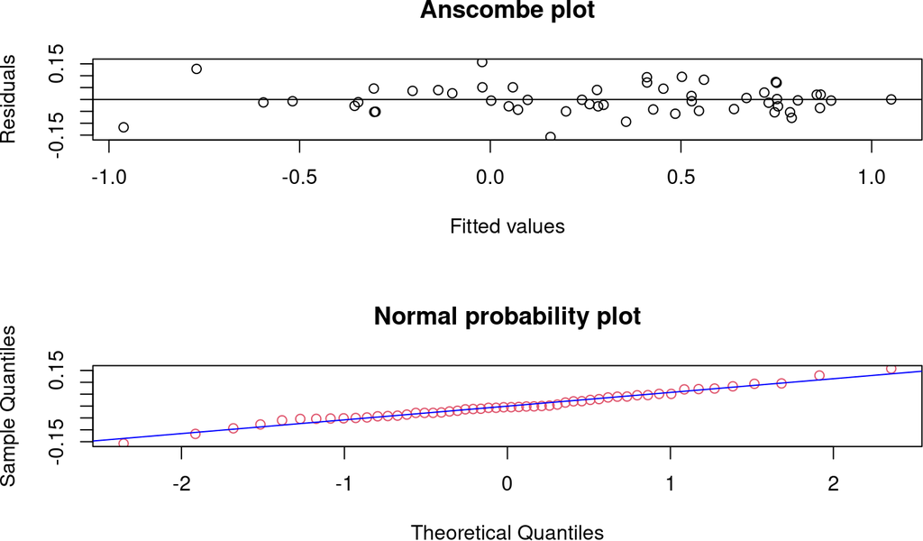

```r
plot(log.lm2$fit, log.lm2$res,xlab="Fitted values",ylab="Residuals", main="Anscombe plot")
abline(h=0)
qqnorm(log.lm2$res,main="Normal probability plot", col=2)
qqline(log.lm2$res, col="blue")
```

```r
par(old.par)
#####################################
# Multicollinearity Analysis
######################################
mod.adr27 <-  lm(logADR27 ~ logT867 + logCS505 + logH505, data=logdata)
summary(mod.adr27) # Multiple R^2 = 0.9936,
```

```
#>
#> Call:
#> lm(formula = logADR27 ~ logT867 + logCS505 + logH505, data = logdata)
#>
#> Residuals:
#>       Min        1Q    Median        3Q       Max
#> -0.060363 -0.020065 -0.005929  0.015471  0.153280
#>
#> Coefficients:
#>             Estimate Std. Error t value Pr(>|t|)
#> (Intercept) -1.77188    0.02975  -59.56  < 2e-16 ***
#> logT867      0.36474    0.01052   34.66  < 2e-16 ***
#> logCS505     0.65020    0.02063   31.52  < 2e-16 ***
#> logH505     -0.02901    0.01007   -2.88  0.00584 **
#> ---
#> Signif. codes:  0 '***' 0.001 '**' 0.01 '*' 0.05 '.' 0.1 ' ' 1
#>
#> Residual standard error: 0.03537 on 50 degrees of freedom
#> Multiple R-squared:  0.9936, Adjusted R-squared:  0.9932
#> F-statistic:  2589 on 3 and 50 DF,  p-value: < 2.2e-16
```

```r
mod.t867 <-  lm(logT867 ~ logADR27 + logH505 + logCS505, data=logdata)
summary(mod.t867) # Multiple R^2 = 0.977,
```

```
#>
#> Call:
#> lm(formula = logT867 ~ logADR27 + logH505 + logCS505, data = logdata)
#>
#> Residuals:
#>      Min       1Q   Median       3Q      Max
#> -0.46512 -0.04505  0.01989  0.05619  0.16509
#>
#> Coefficients:
#>             Estimate Std. Error t value Pr(>|t|)
#> (Intercept)  4.64307    0.16840  27.572   <2e-16 ***
#> logADR27     2.63215    0.07594  34.663   <2e-16 ***
#> logH505      0.07192    0.02739   2.626   0.0114 *
#> logCS505    -1.66719    0.09218 -18.086   <2e-16 ***
#> ---
#> Signif. codes:  0 '***' 0.001 '**' 0.01 '*' 0.05 '.' 0.1 ' ' 1
#>
#> Residual standard error: 0.09503 on 50 degrees of freedom
#> Multiple R-squared:  0.977,  Adjusted R-squared:  0.9757
#> F-statistic: 709.1 on 3 and 50 DF,  p-value: < 2.2e-16
```

```r
mod.cs505 <-  lm(logCS505 ~ logADR27 + logH505 + logT867, data=logdata)
summary(mod.cs505) # Multiple R^2 = 0.9837,
```

```
#>
#> Call:
#> lm(formula = logCS505 ~ logADR27 + logH505 + logT867, data = logdata)
#>
#> Residuals:
#>       Min        1Q    Median        3Q       Max
#> -0.197444 -0.025126  0.008913  0.028843  0.104478
#>
#> Coefficients:
#>             Estimate Std. Error t value Pr(>|t|)
#> (Intercept)  2.64960    0.05473  48.411  < 2e-16 ***
#> logADR27     1.46430    0.04646  31.519  < 2e-16 ***
#> logH505      0.05760    0.01415   4.072 0.000166 ***
#> logT867     -0.52029    0.02877 -18.086  < 2e-16 ***
#> ---
#> Signif. codes:  0 '***' 0.001 '**' 0.01 '*' 0.05 '.' 0.1 ' ' 1
#>
#> Residual standard error: 0.05309 on 50 degrees of freedom
#> Multiple R-squared:  0.9837, Adjusted R-squared:  0.9828
#> F-statistic:  1008 on 3 and 50 DF,  p-value: < 2.2e-16
```

```r
mod.h505 <-  lm(logH505 ~ logADR27 + logCS505 + logT867, data=logdata)
summary(mod.h505) # Multiple R^2 = 0.5784,
```

```
#>
#> Call:
#> lm(formula = logH505 ~ logADR27 + logCS505 + logT867, data = logdata)
#>
#> Residuals:
#>      Min       1Q   Median       3Q      Max
#> -1.50570 -0.11784  0.07984  0.24783  0.85079
#>
#> Coefficients:
#>             Estimate Std. Error t value Pr(>|t|)
#> (Intercept)  -9.3778     3.0009  -3.125 0.002959 **
#> logADR27     -4.9041     1.7029  -2.880 0.005844 **
#> logCS505      4.3236     1.0618   4.072 0.000166 ***
#> logT867       1.6848     0.6417   2.626 0.011444 *
#> ---
#> Signif. codes:  0 '***' 0.001 '**' 0.01 '*' 0.05 '.' 0.1 ' ' 1
#>
#> Residual standard error: 0.4599 on 50 degrees of freedom
#> Multiple R-squared:  0.5784, Adjusted R-squared:  0.5531
#> F-statistic: 22.87 on 3 and 50 DF,  p-value: 1.849e-09
```

```r
# Variance inflation factors
vifs <- c(0.9936, 0.977, 0.9837, 0.5784)
vifs <- 1/(1-vifs)
#Condition numbers
X <- logdata
# X is a copy of logdata
X[,1] <- 1
# the first column of X is 1
# this is for the intercept
X <- as.matrix(X)
# Coerces X to be a matrix
xtx <- t(X) %*% X # Gives X^T X
eigenvalues <- eigen(xtx)$values
kappa <- max(eigenvalues)/min(eigenvalues)
kappa <- sqrt(kappa)
# kappa = 244 is much LARGER than 30!

### Validation statistic
# Fit the log.lm2 model with the first 45 observations
# use the fitted model to predict the remaining 9 observations
# Calculate the mean square error validation statistic
log.lmsub <- lm(logADR37 ~ logADR27 + logT867 + logH505, data=logdata, subset=1:45)
# Now predict all 54 observations using the fitted model
mod.pred <- predict(log.lmsub, logdata, se.fit=TRUE)
mod.pred$fit # provides all the 54 predicted values
```

```
#>            1            2            3            4            5            6            7
#>  0.869733716  0.751945766  0.464377364  0.065106368 -0.750908661  0.676749888  0.863161161
#>            8            9           10           11           12           13           14
#>  0.533123773  0.724024242  0.101489732  0.758165626 -0.009235144  0.262467812  0.499359749
#>           15           16           17           18           19           20           21
#>  0.896844370 -0.512513262  0.860758626  0.288778088  0.638085289  0.691680440  0.047967101
#>           22           23           24           25           26           27           28
#> -0.125585969  0.542661299 -0.298423547 -0.607263492  0.529236907  0.296110240  0.476668407
#>           29           30           31           32           33           34           35
#> -0.343488224  0.286358929  0.732443474  0.740078857 -0.002182982  0.421013296 -0.201423341
#>           36           37           38           39           40           41           42
#>  0.002081194  0.782644479 -0.305494632 -0.978948479  0.130633957  0.245486987  0.071403922
#>           43           44           45           46           47           48           49
#>  0.781436122  0.341921707  0.195907253  0.425131377 -0.094842350  0.754611045  0.444664924
#>           50           51           52           53           54
#>  0.353051544  0.805738645 -0.303182437 -0.356706826  1.052803842
```

```r
logdata$pred <- mod.pred$fit
# Get only last 9
a <- logdata[46:54, ]
validation.residuals <- a$logADR37 - a$pred
validation.stat <- mean(validation.residuals^2)
validation.stat
```

```
#> [1] 0.005814136
```

## 2.9 `err_age` : Error in guessing ages from photographs

This data set contains the errors in guessing ages of 10 Southampton mathematicians. This data set has been used as an exercise in obtaining summary statistics and performing exploratory data analysis in Chapter 2 of the book Sahu (2024).

```r
summary(err_age)
```

```
#>      group         size          females      photo          sex
#>  Min.   : 1   Min.   :2.000   Min.   :0   Min.   : 1.0   Length:550
#>  1st Qu.:14   1st Qu.:2.000   1st Qu.:0   1st Qu.: 3.0   Class :character
#>  Median :28   Median :3.000   Median :1   Median : 5.5   Mode  :character
#>  Mean   :28   Mean   :2.727   Mean   :1   Mean   : 5.5
#>  3rd Qu.:42   3rd Qu.:3.000   3rd Qu.:2   3rd Qu.: 8.0
#>  Max.   :55   Max.   :3.000   Max.   :3   Max.   :10.0
#>      race              est_age         tru_age         error            abs_error
#>  Length:550         Min.   :15.00   Min.   :22.0   Min.   :-23.0000   Min.   : 0.000
#>  Class :character   1st Qu.:23.00   1st Qu.:22.0   1st Qu.: -4.0000   1st Qu.: 2.000
#>  Mode  :character   Median :33.00   Median :35.5   Median :  0.0000   Median : 3.000
#>                     Mean   :38.56   Mean   :39.5   Mean   : -0.9436   Mean   : 5.336
#>                     3rd Qu.:55.00   3rd Qu.:55.0   3rd Qu.:  3.0000   3rd Qu.: 7.000
#>                     Max.   :80.00   Max.   :73.0   Max.   : 18.0000   Max.   :23.000
```

## 2.10 `ffood` : Service times in a fast food restaurant

Service (waiting) times (in seconds) of customers at a fast-food restaurant. Source: Unknown.

```r
summary(ffood)
```

```
#>        AM               PM
#>  Min.   : 38.00   Min.   :45.00
#>  1st Qu.: 53.75   1st Qu.:59.75
#>  Median : 63.50   Median :67.00
#>  Mean   : 68.90   Mean   :66.80
#>  3rd Qu.: 83.75   3rd Qu.:74.25
#>  Max.   :107.00   Max.   :88.00
```

```r
 # 95% Confidence interval for the mean waiting time usig t-distribution
 a <- c(ffood$AM, ffood$PM)
 mean(a) + c(-1, 1) * qt(0.975, df=19) * sqrt(var(a))/sqrt(20)
```

```
#> [1] 59.25467 76.44533
```

```r
 # Two sample t-test for the difference between morning and afternoon times
 t.test(ffood$AM, ffood$PM)
```

```
#>
#>  Welch Two Sample t-test
#>
#> data:  ffood$AM and ffood$PM
#> t = 0.24929, df = 14.201, p-value = 0.8067
#> alternative hypothesis: true difference in means is not equal to 0
#> 95 percent confidence interval:
#>  -15.9434  20.1434
#> sample estimates:
#> mean of x mean of y
#>      68.9      66.8
```

## 2.11 `gasmileage` : Gas mileage of cars

This data set contains gas mileage obtained from four models of a car. This data set has been used to illustrate the concepts of analysis of variance  
in Chapter 19 of the book Sahu (2024).

```r
summary(gasmileage)
```

[output not shown]

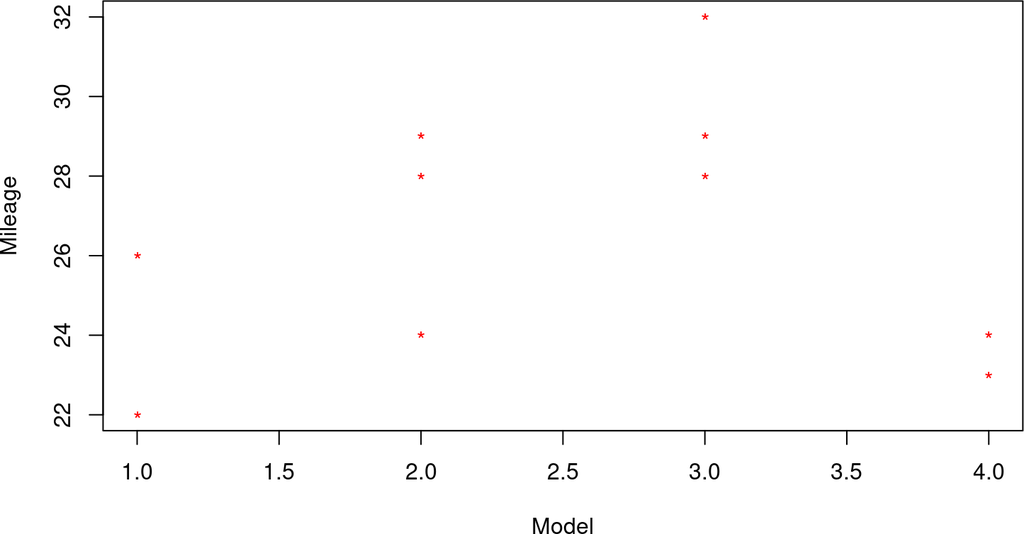

```r
y <- c(22, 26,  28, 24, 29,   29, 32, 28,  23, 24)
xx <- c(1,1,2,2,2,3,3,3,4,4)
# Plot the observations
plot(xx, y, col="red", pch="*", xlab="Model", ylab="Mileage")
```

```r
# Method1: Hand calculation
ni <- c(2, 3, 3, 2)
means <- tapply(y, xx, mean)
vars <- tapply(y, xx, var)
round(rbind(means, vars), 2)
```

```
#>        1  2     3    4
#> means 24 27 29.67 23.5
#> vars   8  7  4.33  0.5
```

```r
sum(y^2) # gives 7115
```

```
#> [1] 7115
```

```r
totalSS <- sum(y^2) - 10 * (mean(y))^2 # gives 92.5
RSSf <- sum(vars*(ni-1)) # gives 31.17
groupSS <- totalSS - RSSf # gives 61.3331.17/6
meangroupSS <- groupSS/3 # gives 20.44
meanErrorSS <- RSSf/6 # gives 5.194
Fvalue <- meangroupSS/meanErrorSS # gives 3.936
pvalue <- 1-pf(Fvalue, df1=3, df2=6)

#### Method 2: Illustrate using dummy variables
#################################
#Create the design matrix X for the full regression model
g <- 4
n1 <- 2
n2 <- 3
n3 <- 3
n4 <- 2
n <- n1+n2+n3+n4
X <- matrix(0, ncol=g, nrow=n)       #Set X as a zero matrix initially
X[1:n1,1] <- 1    #Determine the first column of X
X[(n1+1):(n1+n2),2] <- 1   #the 2nd column
X[(n1+n2+1):(n1+n2+n3),3] <- 1    #the 3rd
X[(n1+n2+n3+1):(n1+n2+n3+n4),4] <- 1    #the 4th
#################################
####Fitting the  full model####
#################################
#Estimation
XtXinv <- solve(t(X)%*%X)
betahat <- XtXinv %*%t(X)%*%y   #Estimation of the coefficients
Yhat <- X%*%betahat   #Fitted Y values
Resids <- y - Yhat   #Residuals
SSE <- sum(Resids^2)   #Error sum of squares
S2hat <- SSE/(n-g)   #Estimation of sigma-square; mean square for error
Sigmahat <- sqrt(S2hat)

##############################################################
####Fitting the reduced model -- the 4 means are equal #####
##############################################################
Xr <- matrix(1, ncol=1, nrow=n)
kr <- dim(Xr)[2]
#Estimation
Varr <- solve(t(Xr)%*%Xr)
hbetar <- solve(t(Xr)%*%Xr)%*%t(Xr)%*% y   #Estimation of the coefficients
hYr = Xr%*%hbetar   #Fitted Y values
Resir <- y - hYr   #Residuals
SSEr <- sum(Resir^2)   #Total sum of squares
###################################################################
####F-test for comparing the reduced model with the full model ####
###################################################################
FStat <- ((SSEr-SSE)/(g-kr))/(SSE/(n-g))  #The test statistic of the F-test
alpha <- 0.05
Critical_value_F <- qf(1-alpha, g-kr,n-g)  #The critical constant of F-test
pvalue_F <- 1-pf(FStat,g-kr, n-g)   #p-value of F-test

modelA <- c(22, 26)
modelB <- c(28, 24, 29)
modelC <- c(29, 32, 28)
modelD <- c(23, 24)

SSerror = sum( (modelA-mean(modelA))^2 ) + sum( (modelB-mean(modelB))^2 )
+ sum( (modelC-mean(modelC))^2 ) + sum( (modelD-mean(modelD))^2 )
```

```
#> [1] 9.166667
```

```r
SStotal <-  sum( (y-mean(y))^2 )
SSgroup <- SStotal-SSerror

####
#### Method 3: Use the  built-in function lm directly

#####################################
aa <- "modelA"
bb <- "modelB"
cc <- "modelC"
dd <- "modelD"
Expl <- c(aa,aa,bb,bb,bb,cc,cc,cc,dd,dd)
is.factor(Expl)
```

```
#> [1] FALSE
```

```r
Expl <- factor(Expl)
model1 <- lm(y~Expl)
summary(model1)
```

```
#>
#> Call:
#> lm(formula = y ~ Expl)
#>
#> Residuals:
#>    Min     1Q Median     3Q    Max
#> -3.000 -1.417  0.000  1.750  2.333
#>
#> Coefficients:
#>             Estimate Std. Error t value Pr(>|t|)
#> (Intercept)   24.000      1.612  14.892 5.77e-06 ***
#> ExplmodelB     3.000      2.081   1.442   0.1994
#> ExplmodelC     5.667      2.081   2.724   0.0345 *
#> ExplmodelD    -0.500      2.279  -0.219   0.8336
#> ---
#> Signif. codes:  0 '***' 0.001 '**' 0.01 '*' 0.05 '.' 0.1 ' ' 1
#>
#> Residual standard error: 2.279 on 6 degrees of freedom
#> Multiple R-squared:  0.6631, Adjusted R-squared:  0.4946
#> F-statistic: 3.936 on 3 and 6 DF,  p-value: 0.07227
```

```r
anova(model1)
```

```
#> Analysis of Variance Table
#>
#> Response: y
#>           Df Sum Sq Mean Sq F value  Pr(>F)
#> Expl       3 61.333 20.4444  3.9358 0.07227 .
#> Residuals  6 31.167  5.1944
#> ---
#> Signif. codes:  0 '***' 0.001 '**' 0.01 '*' 0.05 '.' 0.1 ' ' 1
```

```r
###Alternatively ###

xxf <- factor(xx)
is.factor(xxf)
```

```
#> [1] TRUE
```

```r
model2 <- lm(y~xxf)
summary(model2)
```

```
#>
#> Call:
#> lm(formula = y ~ xxf)
#>
#> Residuals:
#>    Min     1Q Median     3Q    Max
#> -3.000 -1.417  0.000  1.750  2.333
#>
#> Coefficients:
#>             Estimate Std. Error t value Pr(>|t|)
#> (Intercept)   24.000      1.612  14.892 5.77e-06 ***
#> xxf2           3.000      2.081   1.442   0.1994
#> xxf3           5.667      2.081   2.724   0.0345 *
#> xxf4          -0.500      2.279  -0.219   0.8336
#> ---
#> Signif. codes:  0 '***' 0.001 '**' 0.01 '*' 0.05 '.' 0.1 ' ' 1
#>
#> Residual standard error: 2.279 on 6 degrees of freedom
#> Multiple R-squared:  0.6631, Adjusted R-squared:  0.4946
#> F-statistic: 3.936 on 3 and 6 DF,  p-value: 0.07227
```

```r
anova(model2)
```

```
#> Analysis of Variance Table
#>
#> Response: y
#>           Df Sum Sq Mean Sq F value  Pr(>F)
#> xxf        3 61.333 20.4444  3.9358 0.07227 .
#> Residuals  6 31.167  5.1944
#> ---
#> Signif. codes:  0 '***' 0.001 '**' 0.01 '*' 0.05 '.' 0.1 ' ' 1
```

## 2.12 `possum` : Body weight and length of possums in Australian regions

This data set has been used to illustrate multiple linear regression modeling and analysis of variance in Chapter 19 of the book Sahu (2024).

The data set contains body weight and length of possums (tree living furry animals who are mostly nocturnal (marsupial) caught in 7 different regions of Australia. Source: Lindenmayer and Donnelly (1995). (Lindenmayer and Donnelly 1995)

```r
 head(possum)
```

```
#>   Body_Weight Length Location
#> 1         3.5   89.0        1
#> 2         3.3   91.5        1
#> 3         3.5   95.5        1
#> 4         3.1   92.0        1
#> 5         2.8   85.5        1
#> 6         3.0   90.5        1
```

```r
 dim(possum)
```

```
#> [1] 101   3
```

```r
 summary(possum)
```

```
#>   Body_Weight       Length         Location
#>  Min.   :1.80   Min.   :75.00   Min.   :1.000
#>  1st Qu.:2.60   1st Qu.:84.00   1st Qu.:1.000
#>  Median :2.80   Median :88.00   Median :3.000
#>  Mean   :2.88   Mean   :87.16   Mean   :3.604
#>  3rd Qu.:3.20   3rd Qu.:90.00   3rd Qu.:6.000
#>  Max.   :4.20   Max.   :96.50   Max.   :7.000
```

```r
 ## Code lines used in the book
 ## Create a new data set
 poss <- possum
 poss$region <- factor(poss$Location)
 levels(poss$region) <- c("W.A", "S.A", "N.T", "QuL", "NSW", "Vic", "Tas")
 colnames(poss)<-c("y","z","Location", "x")
 head(poss)
```

```
#>     y    z Location   x
#> 1 3.5 89.0        1 W.A
#> 2 3.3 91.5        1 W.A
#> 3 3.5 95.5        1 W.A
#> 4 3.1 92.0        1 W.A
#> 5 2.8 85.5        1 W.A
#> 6 3.0 90.5        1 W.A
```

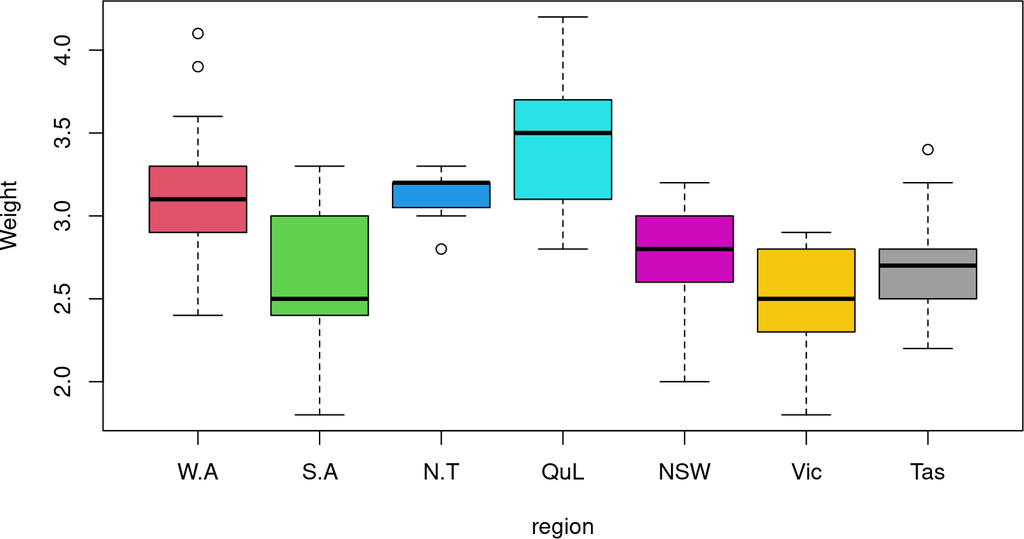

```r
 # Draw side by side boxplots
 boxplot(y~x, data=poss, col=2:8, xlab="region", ylab="Weight")
```

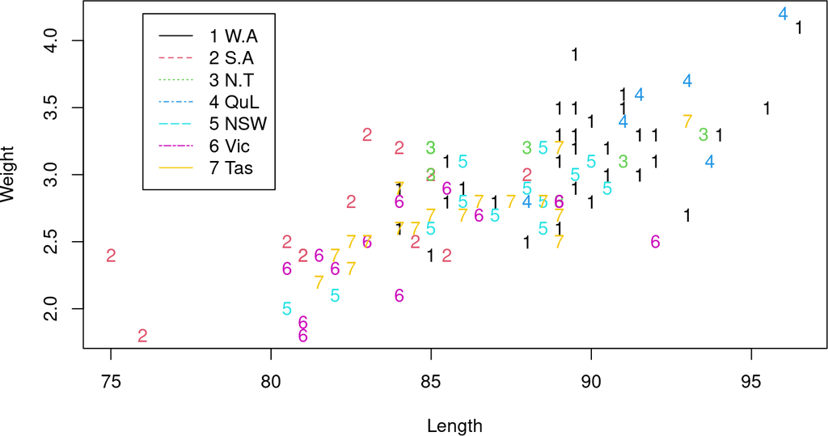

```r
 # Obtain scatter plot
 # Start with a skeleton plot
 plot(poss$z, poss$y, type="n", xlab="Length", ylab="Weight")
 # Add points for the seven regions
 for (i in 1:7) {
    points(poss$z[poss$Location==i],poss$y[poss$Location==i],type="p", pch=as.character(i), col=i)
    }
## Add legends
 legend(x=76, y=4.2, legend=paste(as.character(1:7), levels(poss$x)),  lty=1:7, col=1:7)
```

```r
 # Start  modelling
 #Fit the model with interaction.
 poss.lm1<-lm(y~z+x+z:x,data=poss)
 summary(poss.lm1)
```

```
#>
#> Call:
#> lm(formula = y ~ z + x + z:x, data = poss)
#>
#> Residuals:
#>      Min       1Q   Median       3Q      Max
#> -0.67953 -0.15793  0.01999  0.14591  0.78255
#>
#> Coefficients:
#>               Estimate Std. Error t value Pr(>|t|)
#> (Intercept) -3.5842639  1.5008154  -2.388   0.0191 *
#> z            0.0748795  0.0167202   4.478 2.27e-05 ***
#> xS.A         0.3283443  2.3839136   0.138   0.8908
#> xN.T         6.0527549  3.3898871   1.786   0.0777 .
#> xQuL        -5.9670098  4.5482536  -1.312   0.1930
#> xNSW        -2.4035332  2.7983463  -0.859   0.3927
#> xVic         0.8984502  2.4135144   0.372   0.7106
#> xTas        -0.1263706  2.4142962  -0.052   0.9584
#> z:xS.A      -0.0031036  0.0280484  -0.111   0.9121
#> z:xN.T      -0.0675469  0.0383301  -1.762   0.0815 .
#> z:xQuL       0.0663129  0.0494622   1.341   0.1835
#> z:xNSW       0.0256881  0.0318912   0.805   0.4227
#> z:xVic      -0.0141738  0.0279034  -0.508   0.6128
#> z:xTas      -0.0003129  0.0276672  -0.011   0.9910
#> ---
#> Signif. codes:  0 '***' 0.001 '**' 0.01 '*' 0.05 '.' 0.1 ' ' 1
#>
#> Residual standard error: 0.2828 on 87 degrees of freedom
#> Multiple R-squared:  0.6731, Adjusted R-squared:  0.6243
#> F-statistic: 13.78 on 13 and 87 DF,  p-value: 4.8e-16
```